# eLowQuant_ddPCR Trial

Zachary Gold

2026-04-08

```r
## Load the Data
FILE.PATH <- here("LOD_LOQ/pycno-fullSC-data-Stanford.csv")
DAT_RAW <- read.csv(FILE.PATH) %>% rename(SQ=TargetConcentration, Concentration=MeasuredConcentration) %>%
  mutate(SQ = na_if(SQ, 0)) %>%
  mutate(Concentration = na_if(Concentration, 0),
         PositiveDroplets = na_if(PositiveDroplets,0))
```

# Lesperance eLowQuant LoD and LoQ

### Instructions

This file performs the computations in the publication, ‘A Statistical Model for Calibration and Computation of Detection and Quantification Limits for Low Copy Number Environmental DNA samples’ by Lesperance, Allison, Bergman, Hocking, Helbing, *Environmental DNA*, 2021, 00, 1-12 https://doi.org/10.1002/edn3.220. Code obtained from eLowQuant v20220912.

This code has been modified by Zachary Gold as a part of the manuscript Molecular Star Gazing: Development and Validation of an Environmental DNA Assay for the Imperiled Sunflower Sea Star (*Pycnopodia helianthoides*) to be able to handle both ddPCR and qPCR data. Since this method only requires binary data (0,1) for the model fitting, we apply the eLowQuant method to ddPCR calculations using the number of positive droplets. We recognize that in the ddPCR field there are multiple schools of thought on how to set a LoB and LoD. We include a parameter of minimum number of acceptable droplets (e.g. 1,2,3) as a detection.

- Data set csv file requirements. Columns: Target, Lab, Cq, SQ
- For nondetects, set Cq to be empty or NA value
- For negative controls, set Sq to be empty or 0 or NA value
- Include negative controls in the csv file!
- DO NOT DUPLICATE Target names over different Labs!!
- This code uses observations with nonempty data and where phat <1 (num detect<num technical replicates)
  - Functionally this requires a minimum of 3 standard curve values where fewer than 100% of all replicates amplified. This may require including additional lower standards than are typically run on a qPCR/ddPCR plate
- Only the SQ’s up to the first one with phat==1 are used.
- Allows for variable numbers of SQ levels per Target.
- Assumes SQs == NA are zero, i.e. are negative controls.
- The code uses the R function optim. A convergence code 0 indicates successful completion.
- Ignore warnings if results are sensible.
- EXECUTE EACH CHUNK LOOKING AT THE OUTPUT. IN PARTICULAR, LOOK AT THE GRAPHS IN THE CHUNK CALLED ‘PlotPois’ TO DETERMINE IF THE MODEL IS APPROPRIATE. IT IS NOT APPROPRIATE IF ‘lm Rsq’ is small, i.e. near zero!
- If you wish to knit to pdf AND you do NOT have a version of Latex installed on your computer, then run the following in your RStudio console:  
  install.packages(“tinytex”); tinytex::install_tinytex()

### Process/Summarize samples by Lab; Compute the Poisson estimates of SQ

Hindson et al “High-Throughput Droplet Digital PCR System for Absolute Quantitation of DNA Copy Number”, Anal. Chem., 2011, 83 (22), pp 8604–8610 use a Poisson approximation for quantitation. Before that, Dube et al. 2008, “Mathematical analysis of copy number variation in a DNA sample using digital PCR on a nanofluidic device”, PloS One, Vol 3, Issue 8, e2876, model the number of molecules in each chamber as a Poisson process, giving the relationship between $p$ and $\lambda$.

```
## [1] 10  6
```

```
## dim, before negative controls added
```

Stanford PYCNO

|  | Target | SQ | detect | n | Cqmean | Lab |
| --- | --- | --- | --- | --- | --- | --- |
|  | PYCNO:10 | Min. : 0.0 | Min. :0.00 | Min. :8 | Min. : 1.0 | Stanford:10 |
|  | NA | 1st Qu.: 0.5 | 1st Qu.:6.25 | 1st Qu.:8 | 1st Qu.: 2.0 | NA |
|  | NA | Median : 3.0 | Median :8.00 | Median :8 | Median : 20.0 | NA |
|  | NA | Mean : 1111.7 | Mean :6.20 | Mean :8 | Mean : 2303.1 | NA |
|  | NA | 3rd Qu.: 77.5 | 3rd Qu.:8.00 | 3rd Qu.:8 | 3rd Qu.: 413.5 | NA |
|  | NA | Max. :10000.0 | Max. :8.00 | Max. :8 | Max. :16700.2 | NA |
|  | NA | NA | NA | NA | NA’s :1 | NA |

|  | Target | SQ | detect | n | phat |
| --- | --- | --- | --- | --- | --- |
| 1 | PYCNO | 0 | 0 | 8 | 0 |
| 1.1 | PYCNO | 0 | 0 | 8 | 0 |
| 1.2 | PYCNO | 0 | 0 | 8 | 0 |
| 1.3 | PYCNO | 0 | 0 | 8 | 0 |
| 1.4 | PYCNO | 0 | 0 | 8 | 0 |
| 1.5 | PYCNO | 0 | 0 | 8 | 0 |
| 1.6 | PYCNO | 0 | 0 | 8 | 0 |
| 1.7 | PYCNO | 0 | 0 | 8 | 0 |
| 1.8 | PYCNO | 0 | 0 | 8 | 0 |
| 1.9 | PYCNO | 0 | 0 | 8 | 0 |

### Plot the Poisson estimates (and CI) of SQ for levels that had non-detects

Only the first levels of SQ that had non-detects are analyzed. Red line is least squares linear regression line.

LOOK AT THE GRAPHS IN THE CHUNK CALLED ‘PlotPois’ TO DETERMINE IF THE MODEL IS APPROPRIATE. IT IS NOT APPROPRIATE IF ‘lm Rsq’ is small, i.e. near zero!

*ML* will error if all phats==1

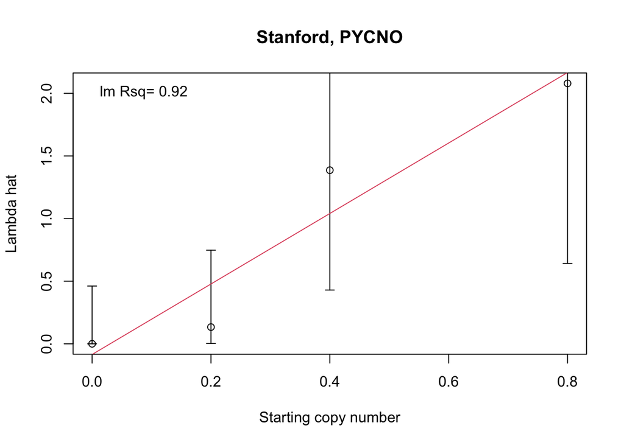

Both the intercept and no intercept models are fit to the data. The ‘best’ of the two models is the one with the largest Likelihood Ratio test p-value. The ‘best’ model will be identified in the chunk called *Manuscript*.

# No Intercept Model

### Estimate Poisson models - no intercept model

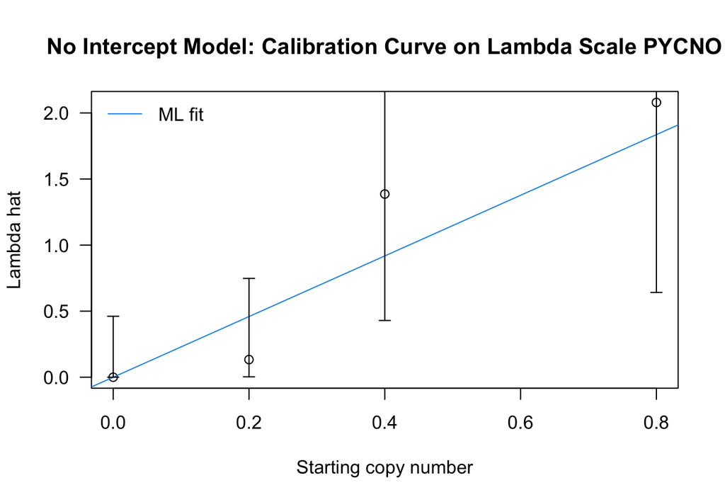

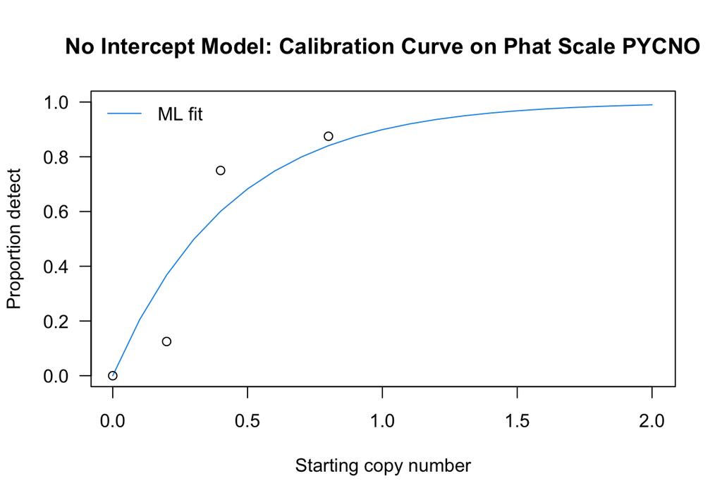

```
##
##
##
##
##  PYCNO
## Convergence= 0
##      Estimate Std.Err Z value  Pr(>z)
## beta    2.296   0.665    3.45 0.00056 ***
## ---
## Signif. codes:  0 '***' 0.001 '**' 0.01 '*' 0.05 '.' 0.1 ' ' 1
## LLR test stat= 3.262979 , df=  3 , p-value= 0.3528286
```

### Estimate predicted Sq given number detects and technical replicates - no intercept (not shown)

The estimated SQ is easily obtained for given new values of nn0=number of replicates, nd0=number detected and the estimated slope betaS as: Shat <- -(log((nn0 - nd0)/nn0)) / betaS[1] The standard errors are obtained from the Hessian matrix (or via the function CalibS0Or.ddLLik()) .

### Estimate predicted Sq given consecutive numbers of detects given number of technical replicates - no intercept

The estimated SQ is easily obtained for given new values of nn0=number of replicates, nd0=number detected and the estimated slope betaS as: Shat <- -(log((nn0 - nd0)/nn0)) / betaS[1] The standard errors are obtained from the Hessian matrix (or via the function CalibS0Or.ddLLik()).

```
##
##  PYCNO
```

```
##  ML estimate of SQ for numbers of detects and 8 replicates
```

| NumDetects | SQ0 | SE_SQ0 |
| --- | --- | --- |
| 0 | 0.000 | NaN |
| 1 | 0.058 | 0.061 |
| 2 | 0.125 | 0.096 |
| 3 | 0.205 | 0.133 |
| 4 | 0.302 | 0.177 |
| 5 | 0.427 | 0.234 |
| 6 | 0.604 | 0.319 |
| 7 | 0.906 | 0.485 |

| alpha | SEalpha | SQ0 | SE_SQ0 |
| --- | --- | --- | --- |
| 1.276 | 0.000 | 0.000 | NaN |
| 2.296 | 0.665 | 0.058 | 0.061 |
| 2.296 | 0.665 | 0.125 | 0.096 |
| 2.296 | 0.665 | 0.205 | 0.133 |
| 2.296 | 0.665 | 0.302 | 0.177 |
| 2.296 | 0.665 | 0.427 | 0.234 |
| 2.296 | 0.665 | 0.604 | 0.319 |
| 2.296 | 0.665 | 0.906 | 0.485 |

# Intercept Model

### Estimate Poisson models - intercept model

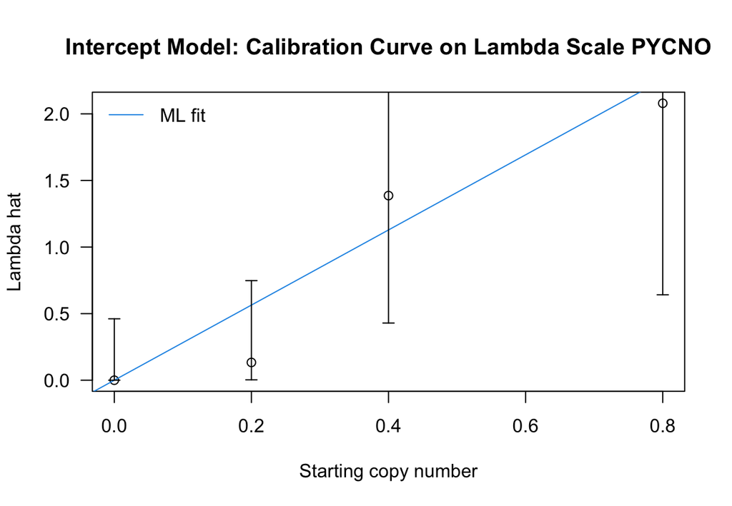

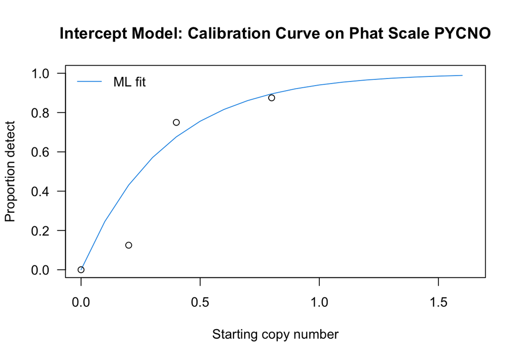

```
##
##
##
##
##  PYCNO
## Convergence= 0
##       Estimate  Std.Err Z value Pr(>z)
## alpha 8.63e-11 8.04e-01    0.00   1.00
## beta  2.82e+00 1.96e+00    1.44   0.15
## LLR test stat= 3.794387 , df=  2 , p-value= 0.149989
```

### Estimate predicted Sq given number detects and technical replicates - intercept model (not shown)

### Estimate predicted Sq given consecutive numbers of detects given number of technical replicates - intercept model

The estimated SQ is easily obtained for given new values of nn0=number of replicates, nd0=number detected and the estimated slope betaS as: Shat <- -(log((nn0 - nd0)/nn0) + betaS[1]) / betaS[2] The standard errors are obtained from the Hessian matrix (or via the function CalibS0.ddLLik()).

```
##
##  PYCNO
```

```
##  ML estimate of SQ for numbers of detects and 8 replicates
```

| NumDetects | SQ0 | SE_SQ0 |
| --- | --- | --- |
| 0 | 0.000 | 0.000 |
| 1 | 0.046 | 0.287 |
| 2 | 0.101 | 0.242 |
| 3 | 0.166 | 0.214 |
| 4 | 0.245 | 0.197 |
| 5 | 0.349 | 0.205 |
| 6 | 0.492 | 0.264 |
| 7 | 0.736 | 0.435 |

# LOB, LOD, LOQ

### Determine Lc, Ld, Lq (LOB, LOD, LOQ) - no intercept model

Follows Lavagnini and Magno 2007, Mass Spectrometry Reviews *The notation in the paper was changed from the Lavagnini 2007 paper and is shown in brackets here.*

- Lc (*LOB Limit of blank*) = critical level is the assay signal above which a response is reliably attributed to the presence of analyte
- Ld (*Ld = expected number detects out of NN replicates at concentration LOD*) = signal corresponding to an analyte concentration xd (*=LOD Limit of Detection*) level which may be a priori expected to be recognized
- Lq = quantification limit is a signal with a precision which satisfies an expected value ($=\gamma_Q$)

Lc corresponds to a critical response level or a false positive rate, i.e. critical number of detects given NN replicates, above which we would reject the null hypothesis that the concentration/copy number is zero at alpha = alphaLc ($=\gamma_{FP}$). It is the critical response level corresponding to the false positive rate of alphaLc. Essentially, the test is positive if the Y~Binomial(m, p) > Lc. The False Positive Rate is P(Y > Lc | S=0).

Ld is computed to correspond to the false negative rate, beta = betaLd ($=\gamma_{FN}$) here. It is computed so that the probability of observing a new (unknown concentration) response less than or equal to Lc is less than or equal to betaLd. The probability of observing Lc or less detects if the concentration is xd (*=LOD Limit of Detection*) or more is less than or equal to betaLd. The values of Lc depend on the number of replicates, NN, so xd does as well. Ld is the expected number of detects at values xd (*=LOD Limit of Detection*) and NN replicates. False negative rate Ld computation: P(Y <= Lc | p_xd) <= betaLd, ($=\gamma_{FN}$) and solve for xd (*=LOD Limit of Detection*).

Lq is less well defined. The literature suggests using Lq = beta0 + 10 s.e.(beta0), but this uses the normality assumption. Other literature suggests using the “analyte concentration xq (*=LOQ Limit of Quantification*) for which the experimental relative standard deviation of the responses reaches a fixed level ($=\gamma_Q$), for example, the level 0.1.” Lavagnini and Magno 2007. I interpret the term “relative standard deviation” to mean the coefficient of variation, CV = sd/mean.

In the exercise below, we use the fits from the ML models to estimate the Lc, Ld and Lq, for various values of NN replicates for a new observation, i.e. a new (unknown concentration) response number of detects. Both the intercept and no intercept models are considered.

### Determine Lc, Ld, Lq (LOB, LOD and LOQ) - intercept model

### Estimates, Lc, Ld, Lq (LOB, LOD, LOQ) and confidence limits for a given number of technical reps NN[NNi]

Chooses the model (intercept versus no intercept) with the best LLR test fit, i.e. the largest p-value for the LLR test. A table of values for all assays is printed.

```
## Limits for best choice model for N= 8
```

```
## InterModel      alpha        aSE       beta        bSE         Lc      SdLow
##       0.00       0.00       0.00       2.30       0.67       0.00       0.10
##         Sd       SdUp      SqLow         Sq       SqUp
##       0.16       0.38       0.39       0.62       1.43
```

### Tables and Graphs for the manuscript

*Revised for general use to use all eligible targets.*

#### Intercept model: Estimates, Critical, Detection, Quantification Limits and CIs

```r
xdxq.all.PR <- cbind(alphabeta.se, xdxq.all)
xdxq.all.PR <- xdxq.all.PR[nrowTarget>2, , drop=FALSE]
xdxq.all.PR <- xdxq.all.PR[order(row.names(xdxq.all.PR)), , drop=FALSE]
colnames(xdxq.all.PR)[5:11] <- c('LOB','LODL','LOD','LODU','LOQL','LOQ','LOQU')
knitr::kable(round(xdxq.all.PR,
                    digits=1),
                    format="pandoc", digits=1,
                     results="asis")
```

|  | alpha | aSE | beta | bSE | LOB | LODL | LOD | LODU | LOQL | LOQ | LOQU |
| --- | --- | --- | --- | --- | --- | --- | --- | --- | --- | --- | --- |
| PYCNO | 0 | 0.8 | 2.8 | 2 | 0 | 0 | 0.1 | 36.4 | 0 | 0.5 | 140.7 |

#### No intercept model: Estimates, Critical, Detection, Quantification Limits and CIs

```r
# No Intercept table


xdxq.all0.PR <- cbind(alphabeta0.se, xdxq.all0)
xdxq.all0.PR <- xdxq.all0.PR[nrowTarget>2, , drop=FALSE]
xdxq.all0.PR <- xdxq.all0.PR[order(row.names(xdxq.all0.PR)), , drop=FALSE]
colnames(xdxq.all0.PR)[5:11] <- c('LOB','LODL','LOD','LODU','LOQL','LOQ','LOQU')
knitr::kable(round(xdxq.all0.PR,
                    digits=1),
                    format="pandoc", digits=1,
                     results="asis")
```

|  | alpha | aSE | beta | bSE | LOB | LODL | LOD | LODU | LOQL | LOQ | LOQU |
| --- | --- | --- | --- | --- | --- | --- | --- | --- | --- | --- | --- |
| PYCNO | 0 | 0 | 2.3 | 0.7 | 0 | 0.1 | 0.2 | 0.4 | 0.4 | 0.6 | 1.4 |

#### Estimates, Critical, Detection, Quantification Limits and CIs

```r
xdxq.choice.PR <- xdxq.choice[nrowTarget>2, -1, drop=FALSE]
xdxq.choice.PR <- xdxq.choice.PR[order(row.names(xdxq.choice.PR)), , drop=FALSE]
colnames(xdxq.choice.PR)[5:11] <- c('LOB','LODL','LOD','LODU','LOQL','LOQ','LOQU')
knitr::kable(round(xdxq.choice.PR,
                    digits=1),
                    format="pandoc", digits=1,
                     results="asis")
```

|  | alpha | aSE | beta | bSE | LOB | LODL | LOD | LODU | LOQL | LOQ | LOQU |
| --- | --- | --- | --- | --- | --- | --- | --- | --- | --- | --- | --- |
| PYCNO | 0 | 0 | 2.3 | 0.7 | 0 | 0.1 | 0.2 | 0.4 | 0.4 | 0.6 | 1.4 |

#### Data

```r
Targeti <-1
  jmat <- nndetect[[Targeti]][, c(2:4, 12, 10)]
  row.names(jmat) <- NULL
  names(jmat) <- c("S", "num.detect", "n", "p.tilde", "lambda.tilde")
  knitr::kable(jmat,
                     format="pandoc", digits=3, caption=uTargets[Targeti])
```

PYCNO

| S | num.detect | n | p.tilde | lambda.tilde |
| --- | --- | --- | --- | --- |
| 0.0 | 0 | 8 | 0.000 | 0.000 |
| 0.2 | 1 | 8 | 0.125 | 0.134 |
| 0.4 | 6 | 8 | 0.750 | 1.386 |
| 0.8 | 7 | 8 | 0.875 | 2.079 |

#### Intercept Model

```r
#V20220912 printed all output results

# Print regression outputs
#  if (Calib.choice[Targeti]){
  cat("\n", as.character(uTargets[Targeti]), "\n")
```

```
##
##  PYCNO
```

```r
  cat("Convergence=", Calib.fit.res$convergence[Targeti], "\n")
```

```
## Convergence= 0
```

```r
  printCoefmat(Calib.fit.estimates[[Targeti]], digits=3)
```

```
##       Estimate  Std.Err Z value Pr(>z)
## alpha 8.63e-11 8.04e-01    0.00   1.00
## beta  2.82e+00 1.96e+00    1.44   0.15
```

```r
  cat('LLR test stat=', Calib.fit.res$LLR[Targeti], ', df= ',
      Calib.fit.res$degf[Targeti], ', p-value=', Calib.fit.res$Pval[Targeti], "\n\n")
```

```
## LLR test stat= 3.794387 , df=  2 , p-value= 0.149989
```

#### No Intercept Model

```r
   cat("\n", as.character(uTargets[Targeti]), "\n")
```

```
##
##  PYCNO
```

```r
   cat("Convergence=", Calib.fit.res0$convergence[Targeti], "\n")
```

```
## Convergence= 0
```

```r
   printCoefmat(Calib.fit.estimates0[[Targeti]], digits=3)
```

```
##      Estimate Std.Err Z value  Pr(>z)
## beta    2.296   0.665    3.45 0.00056 ***
## ---
## Signif. codes:  0 '***' 0.001 '**' 0.01 '*' 0.05 '.' 0.1 ' ' 1
```

```r
   cat('LLR test stat=', Calib.fit.res0$LLR[Targeti], ', df= ',
      Calib.fit.res0$degf[Targeti], ', p-value=', Calib.fit.res0$Pval[Targeti], "\n\n")
```

```
## LLR test stat= 3.262979 , df=  3 , p-value= 0.3528286
```

```r
#  }
```

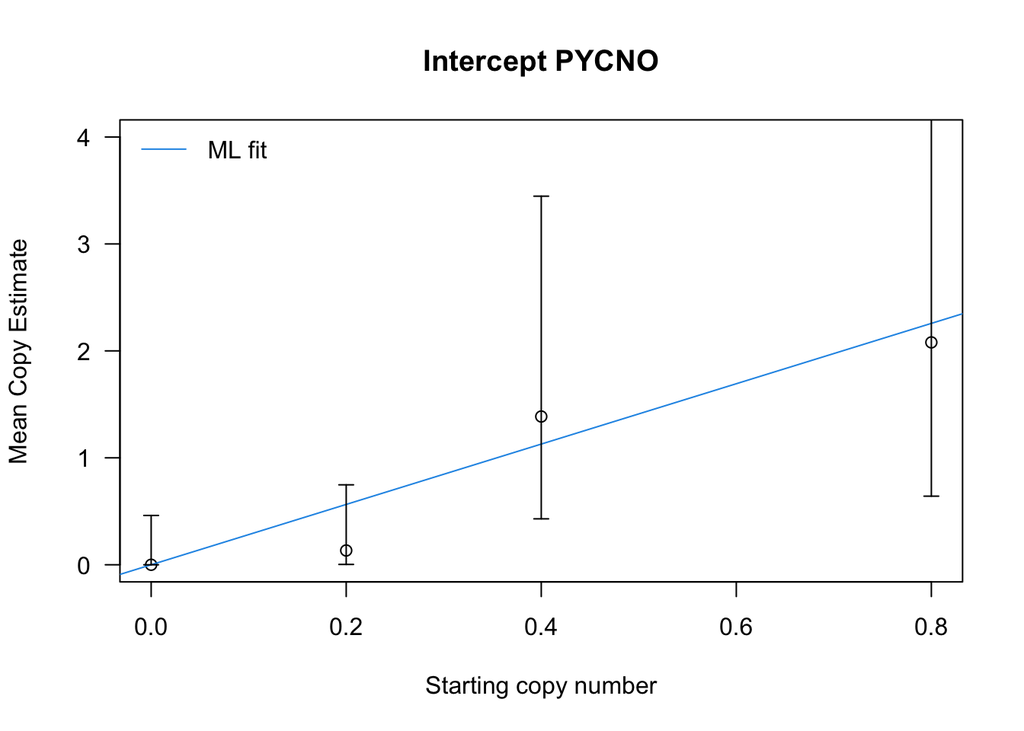

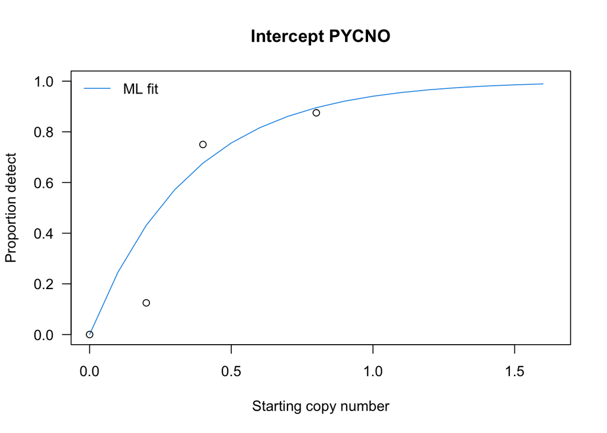

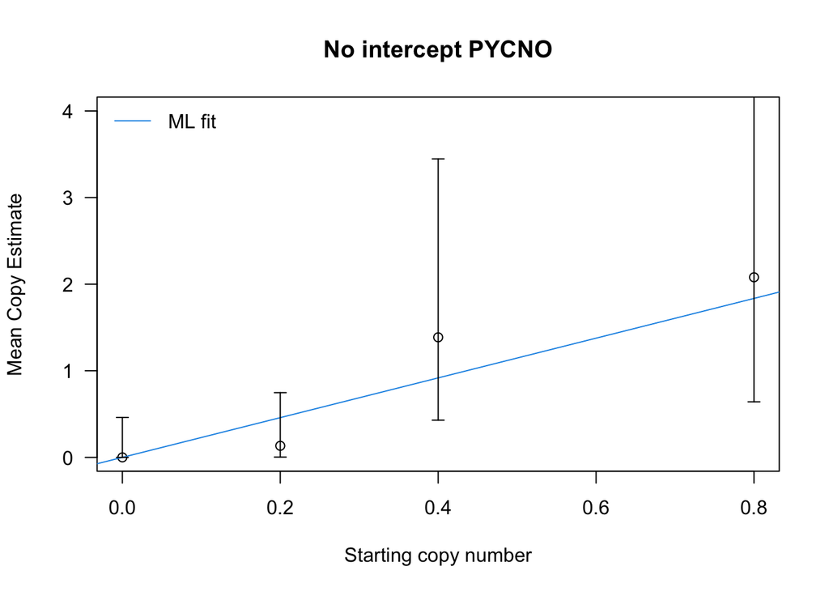

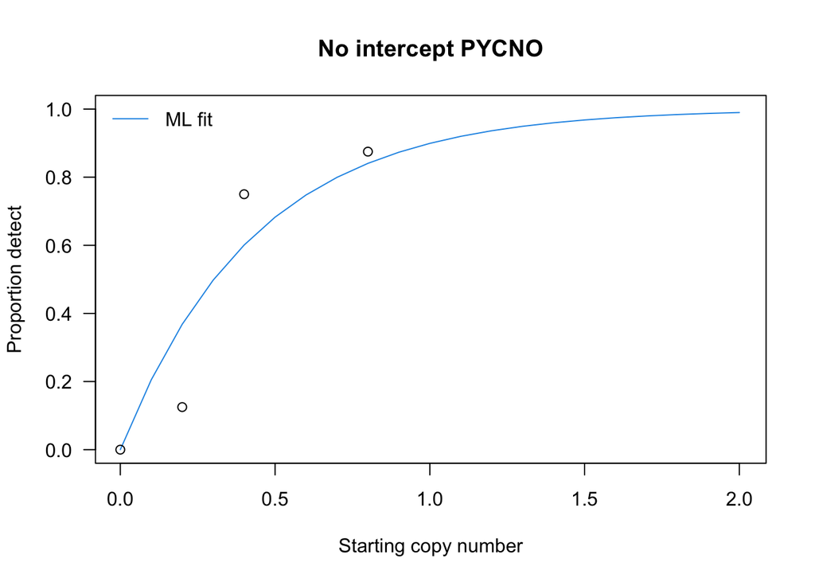

```r
# Plots of fits using chosen no-intercept/intercept model
#V20220912 plotted all output results

for(Targeti in ManuTargets){
  Target.dat <- nndetect[[Targeti]]

#  if (Calib.choice[Targeti]){
  Calib.fit <- Calib.fit.all[[Targeti]]
  Calib.fitted <- Calib.fit$par[1] + Calib.fit$par[2]*  Target.dat$SQ

  # Plot calibration curve on lambda scale
  maxSQ <- max(Target.dat$SQ)
  maxlamhat <- max(Target.dat$lamhat)

  plot(Target.dat$SQ, Target.dat$lamhat, xlog=TRUE,
       ylab='Mean Copy Estimate',
       xlab='Starting copy number',
       ylim=c(0, 4), xlim=c(0, maxSQ), las=1,
#      ylim=c(0, maxlamhat), xlim=c(0, maxSQ), las=1,
       main=paste('Intercept',uTargets[Targeti]))
  abline(Calib.fit$par[1], Calib.fit$par[2], col=4)
  legend("topleft", legend=c('ML fit'), lty=1, col=4, bty="n")
  arrows(Target.dat$SQ, Target.dat$Lamhatex.Lower, Target.dat$SQ,
         Target.dat$Lamhatex.Upper,
         length=0.05, angle=90, code=3)

  # Plot calibration curve on phat scale
  # Compute minSQ such that phat~=1 (1-phat = .99)
  maxSQa <-max( -(Calib.fit$par[1] + log(.01))/Calib.fit$par[2], maxSQ)
  sqs <- seq(0, maxSQa, by=.1)
  Calib.phat <- 1 - exp(-(Calib.fit$par[1] + Calib.fit$par[2] * sqs))

  plot(sqs, Calib.phat, xlog=TRUE,
       ylab='Proportion detect', xlab='Starting copy number', type='l', col=4, las=1,
       ylim=c(0, 1), xlim=c(0, maxSQa),  main=paste('Intercept',uTargets[Targeti]))
  points(Target.dat$SQ, Target.dat$phat)
  legend("topleft", legend=c('ML fit'), lty=1, col=4, bty="n")

#  } else {

  #Compute fitted values for ML model
  Calib.fit <- Calib.fit.all0[[Targeti]]
  Calib.fitted <- Calib.fit$par *  Target.dat$SQ

  # Plot calibration curve on lambda scale
  maxSQ <- max(Target.dat$SQ)
  maxlamhat <- max(Target.dat$lamhat)

  plot(Target.dat$SQ, Target.dat$lamhat, xlog=TRUE,
       ylab='Mean Copy Estimate', xlab='Starting copy number',
       ylim=c(0, 4), xlim=c(0, maxSQ), las=1,
 #     ylim=c(0, maxlamhat), xlim=c(0, maxSQ), las=1,
      main=paste('No intercept', uTargets[Targeti]))
  abline(0, Calib.fit$par, col=4)
  legend("topleft", legend=c('ML fit'), lty=1, col=4, bty="n")
  arrows(Target.dat$SQ, Target.dat$Lamhatex.Lower, Target.dat$SQ,
         Target.dat$Lamhatex.Upper,
         length=0.05, angle=90, code=3)

  # Plot calibration curve on phat scale
  # Compute minSQ such that phat~=1 (1-phat = .99)
  maxSQa <-max( -( log(.01))/Calib.fit$par, maxSQ)
  sqs <- seq(0, maxSQa, by=.1)
  Calib.phat <- 1 - exp(-( Calib.fit$par * sqs))

  plot(sqs, Calib.phat, xlog=TRUE,
       ylab='Proportion detect', xlab='Starting copy number', type='l', col=4, las=1,
       ylim=c(0, 1), xlim=c(0, maxSQa),  main=paste('No intercept', uTargets[Targeti]))
  points(Target.dat$SQ, Target.dat$phat)
  legend("topleft", legend=c('ML fit'), lty=1, col=4, bty="n")

}
```

```r
  cat("\n\n")
```

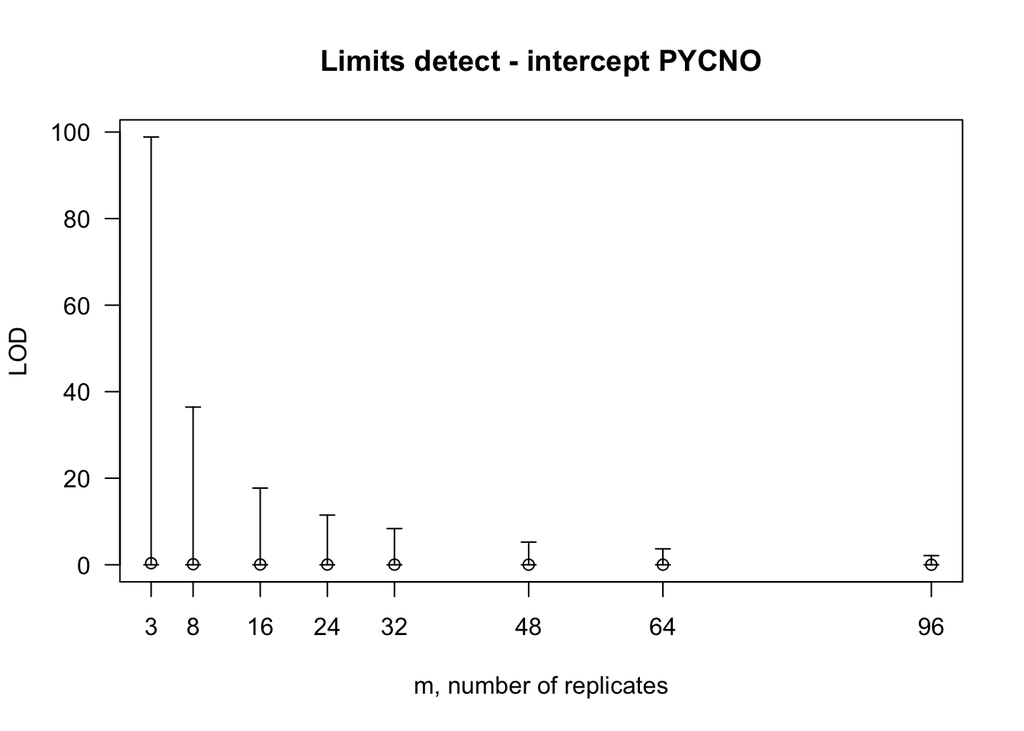

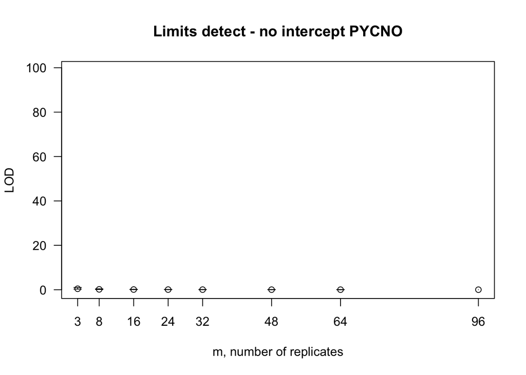

```r
#}

# Plot limits of detection
# Note:  the same vertical scale is used for all assays
#V20220912 plotted all output results

max.xd_upper <- max(xd_upper.all[ManuTargets,], xd_upper.all0[ManuTargets,])
for(Targeti in ManuTargets){
#max.xq_lower <- max(xq_lower.all[Targeti,])

#  if (Calib.choice[Targeti]){
  plot(NN, xd.all[Targeti,], ylab='LOD',
       xlab='m, number of replicates', xaxt='n',
       ylim=c(0, max.xd_upper), xlim=c(min(NN), max(NN)),  las=1,
       main=paste('Limits detect - intercept', uTargets[Targeti]))
#        main=uTargets[Targeti])
  axis(1, at=NN)

  # Transformed Exact CI
  arrows(NN, xd_lower.all[Targeti,], NN,
        xd_upper.all[Targeti,],
         length=0.05, angle=90, code=3)
#  } else {


  plot(NN, xd.all0[Targeti,], ylab='LOD',
       xlab='m, number of replicates', xaxt='n',
       ylim=c(0, max.xd_upper), xlim=c(min(NN), max(NN)),  las=1,
       main=paste('Limits detect - no intercept', uTargets[Targeti]))
#       main=uTargets[Targeti])
  axis(1, at=NN)

  # Transformed Exact CI
  arrows(NN, xd_lower.all0[Targeti,], NN,
        xd_upper.all0[Targeti,],
         length=0.05, angle=90, code=3)
}
```

```r
  cat("\n\n")
```

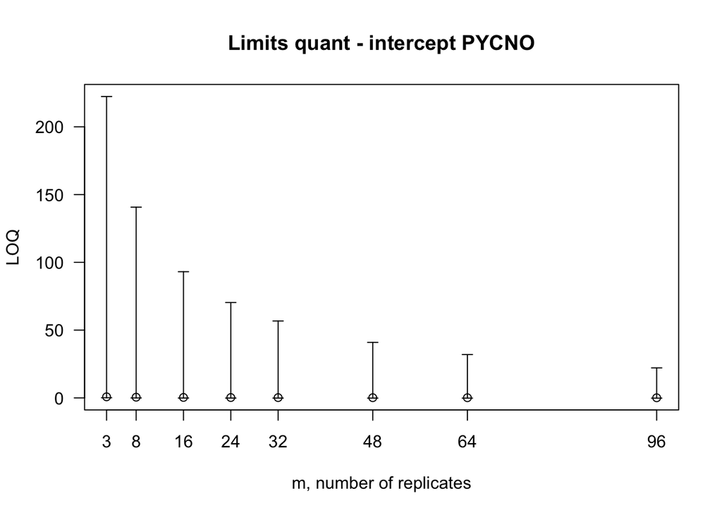

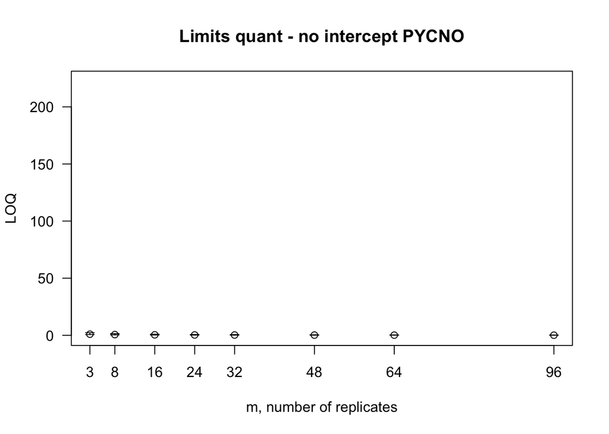

```r
#}

# Plots limits of Quantification
# Note:  the same vertical scale is used for all assays
#V20220912 plotted all output results

max.xq_lower <- max(xq_lower.all[ManuTargets,], xq_lower.all0[ManuTargets,])
for(Targeti in ManuTargets){

#  if (Calib.choice[Targeti]){
  plot(NN, xq.all[Targeti,], ylab='LOQ',
       xlab='m, number of replicates', xaxt='n',
       ylim=c(0, max.xq_lower), xlim=c(min(NN), max(NN)),  las=1,
       main=paste('Limits quant - intercept', uTargets[Targeti]))
#        main=uTargets[Targeti])
  axis(1, at=NN)

  # Transformed Exact CI
  arrows(NN, xq_upper.all[Targeti,], NN,
        xq_lower.all[Targeti,],
         length=0.05, angle=90, code=3)
#  } else {

#max.xq_lower <- max(xq_lower.all0[Targeti,])

  plot(NN, xq.all0[Targeti,], ylab='LOQ',
       xlab='m, number of replicates', xaxt='n',
       ylim=c(0, max.xq_lower), xlim=c(min(NN), max(NN)),  las=1,
       main=paste('Limits quant - no intercept', uTargets[Targeti]))
#     main=uTargets[Targeti])
  axis(1, at=NN)

  # Transformed Exact CI
  arrows(NN, xq_upper.all0[Targeti,], NN,
        xq_lower.all0[Targeti,],
         length=0.05, angle=90, code=3)
}
```